# Lab7_code_arca_v2

Foundations of Machine Learning Frameworks

CSCN8010 - Winter 2024

Professor: Ran Feldesh

Student: Arcadio de Paula Fernandez

# Practical Lab 7- Performance Metrics for Classification Problems

## Importing all the essential libraries and sub modules

```python
import numpy as np

# plotting modules
from matplotlib import pyplot as plt
import matplotlib.patches as patches  # for curved arrows
import seaborn as sns

# The web source of the MNIST dataset that we will work with
from sklearn.datasets import fetch_openml

# The classifiers we will use in this notebook
from sklearn.linear_model import SGDClassifier
from sklearn.dummy import DummyClassifier
from sklearn.ensemble import RandomForestClassifier

# Splitting the data into training, test and validation
from sklearn.model_selection import train_test_split

# # cross validation functions
# from sklearn.model_selection import cross_validate, cross_val_predict

# performance metrics
from sklearn.metrics import confusion_matrix, precision_score, recall_score, f1_score, precision_recall_curve, roc_curve, roc_auc_score
```

# 1. Introduction: A brief introduction to the problem and the data.

### 1.1. A brief introduction to the problem

The MNIST database (Modified National Institute of Standards and Technology database) is a large database of handwritten digits that is commonly used for training various image processing systems, here you can access the [Wikipedia article](https://en.wikipedia.org/wiki/MNIST_database) describing MNIST.

The MNIST dataset, commonly used in machine learning for handwritten digit recognition, consists of 70,000 images (60,000 for training and 10,000 for testing) of handwritten digits from 0 to 9.Each image is 28x28 pixels in size. The database is also widely used for training and testing in the field of machine learning.

### 1.2. Obtaining the Data

We load the data from `openml.org`. [openml.org](https://openml.org/) is a public repository for machine learning data and experiments, that allows everybody to upload open datasets.The `sklearn.datasets` package is able to download datasets from the repository using the function `sklearn.datasets.fetch_openml` ([sklearn User Guide](https://scikit-learn.org/stable/datasets/loading_other_datasets.html#openml), [sklearn docs](https://scikit-learn.org/stable/modules/generated/sklearn.datasets.fetch_openml.html)).

```python
mnist = fetch_openml('mnist_784', as_frame=False, parser='auto')
```

# 2. Exploratory data analysis - EDA

When these images are prepared for use in machine learning models, especially in libraries like Scikit-Learn, they are often "flattened" from their original 2D shape into a 1D vector.

The conversion process looks like this:

Original image shape: 28x28 pixels (2D)

After flattening: 784 pixels (1D)

The process of flattening the images into 1D vectors doesn't remove any information about the image; it just rearranges the pixel values into a linear format. This allows us to use these images with machine learning algorithms that expect input data in a vector format.

In sum, we will analyze 70,000 images of handwritten digits where each image was transformed from a 2D format (28x28 pixels) to a 1D format (784 elements), a vector format.

The object that is returned back from `fetch_openml` is a `Bunch` object ([docs](https://scikit-learn.org/stable/modules/generated/sklearn.utils.Bunch.html)). This is a standard `sklearn` object, used for storing datasets.

When we use fetch_openml or similar functions in Scikit-Learn to load a dataset, the data is returned as a Bunch object. This Bunch object is a container that holds various components of the dataset, including the data itself, labels (targets), a description of the dataset, feature names, and potentially more. It behaves similarly to a Python dictionary but also allows you to access its contents as attributes.

```python
type(mnist)
```

```
sklearn.utils._bunch.Bunch
```

Bunch object behaves similarly to a Python dictionary but also allows you to access its contents as attributes. So we can print out all of its keys:

```python
list(mnist)
```

```
['data',
 'target',
 'frame',
 'categories',
 'feature_names',
 'target_names',
 'DESCR',
 'details',
 'url']
```

```python
mnist.keys()
```

```
dict_keys(['data', 'target', 'frame', 'categories', 'feature_names', 'target_names', 'DESCR', 'details', 'url'])
```

Here we are going to use `mnist.data[0]` that refers to the first image in the MNIST dataset, represented as a flattened 1D array (or vector) of 784 elements:

```python
mnist.data[0]
```

```
array([  0,   0,   0,   0,   0,   0,   0,   0,   0,   0,   0,   0,   0,
         0,   0,   0,   0,   0,   0,   0,   0,   0,   0,   0,   0,   0,
         0,   0,   0,   0,   0,   0,   0,   0,   0,   0,   0,   0,   0,
         0,   0,   0,   0,   0,   0,   0,   0,   0,   0,   0,   0,   0,
         0,   0,   0,   0,   0,   0,   0,   0,   0,   0,   0,   0,   0,
         0,   0,   0,   0,   0,   0,   0,   0,   0,   0,   0,   0,   0,
         0,   0,   0,   0,   0,   0,   0,   0,   0,   0,   0,   0,   0,
         0,   0,   0,   0,   0,   0,   0,   0,   0,   0,   0,   0,   0,
         0,   0,   0,   0,   0,   0,   0,   0,   0,   0,   0,   0,   0,
         0,   0,   0,   0,   0,   0,   0,   0,   0,   0,   0,   0,   0,
         0,   0,   0,   0,   0,   0,   0,   0,   0,   0,   0,   0,   0,
         0,   0,   0,   0,   0,   0,   0,   0,   0,   3,  18,  18,  18,
       126, 136, 175,  26, 166, 255, 247, 127,   0,   0,   0,   0,   0,
         0,   0,   0,   0,   0,   0,   0,  30,  36,  94, 154, 170, 253,
       253, 253, 253, 253, 225, 172, 253, 242, 195,  64,   0,   0,   0,
```

[output cut: 46 more lines]

The object also contains a description of the dataset that it contains. This is provided by the curators of the dataset. It can be accessed using the `DESCR` method of the object.

```python
print(mnist.DESCR)
```

```
**Author**: Yann LeCun, Corinna Cortes, Christopher J.C. Burges
**Source**: [MNIST Website](http://yann.lecun.com/exdb/mnist/) - Date unknown
**Please cite**:

The MNIST database of handwritten digits with 784 features, raw data available at: http://yann.lecun.com/exdb/mnist/. It can be split in a training set of the first 60,000 examples, and a test set of 10,000 examples

It is a subset of a larger set available from NIST. The digits have been size-normalized and centered in a fixed-size image. It is a good database for people who want to try learning techniques and pattern recognition methods on real-world data while spending minimal efforts on preprocessing and for…

With some classification methods (particularly template-based methods, such as SVM and K-nearest neighbors), the error rate improves when the digits are centered by bounding box rather than center of mass. If you do this kind of pre-processing, you should report it in your publications. The MNIST da…

The MNIST training set is composed of 30,000 patterns from SD-3 and 30,000 patterns from SD-1. Our test set was composed of 5,000 patterns from SD-3 and 5,000 patterns from SD-1. The 60,000 pattern training set contained examples from approximately 250 writers. We made sure that the sets of writers …

Downloaded from openml.org.
```

Let's look into the `data` and the `target` attributes.

By using `mnist.data.shape` we got as an output our 70,000 images of handwritten digits where each image was transformed from a 2D format (28x28 pixels) to a 1D format (784 elements), a vector format.

```python
mnist.data.shape
```

```
(70000, 784)
```

Let's rename these objects to our familiar conventions, that are common regardless of the specific dataset being studied:

```python
X = mnist.data
y = mnist.target
```

It will be good at this point to look at actual data instance, which is a single image:

```python
def plot_digit(image_data):
    image = image_data.reshape(28, 28)
    plt.imshow(image, cmap="binary")
    plt.axis("off")
```

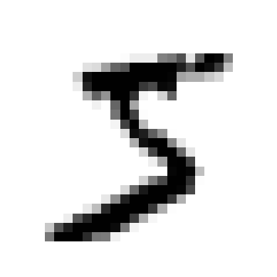

```python
some_digit = X[0]  # here we are using the first image in the dataset
plot_digit(some_digit)
plt.show()
```

```python
y[0]  # the label for the first image
```

```
'5'
```

For better famliarity with the dataset, let's plot the first 100 images.

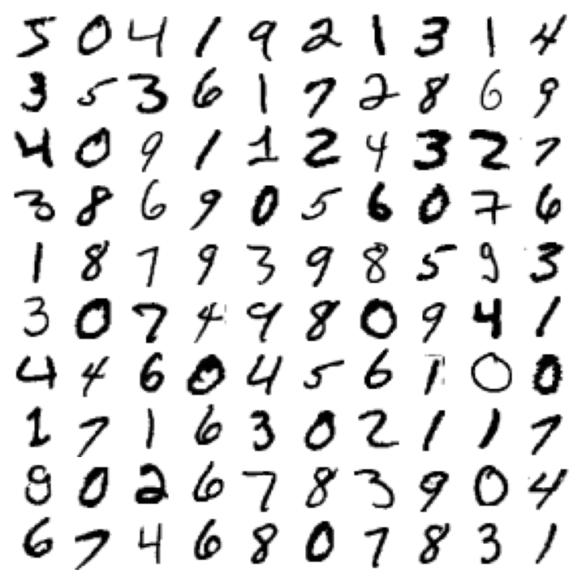

```python
plt.figure(figsize=(9, 9))
for idx, image_data in enumerate(X[:100]):
    plt.subplot(10, 10, idx + 1)
    plot_digit(image_data)
plt.subplots_adjust(wspace=0, hspace=0)
plt.show()
```

# 3. Preprocessing the Data

The MNIST dataset contains images of handwritten digits, encompassing 10 classes. Each class corresponds to one digit, ranging from 0 to 9. These classes represent the following digits: 0, 1, 2, 3, 4, 5, 6, 7, 8 and 9. These 10 classes cover all the possible digits in decimal number representation, making the MNIST.

### 3.1. Choosing the number of classes you want to have

For the purpose of our study, we are going to choose 4 classes, the following digits: 0, 1, 2 and 3.

```python
# Converting targets to integers for easier filtering
mnist.target = mnist.target.astype(int)

# Filtering for classes 0 through 3
mask = mnist.target < 4
data_filtered = mnist.data[mask]
target_filtered = mnist.target[mask]

# Checking the shapes and unique classes in the filtered target
data_filtered_shape = data_filtered.shape
target_filtered_shape = target_filtered.shape
unique_classes = np.unique(target_filtered)

data_filtered_shape, target_filtered_shape, unique_classes
```

```
((28911, 784), (28911,), array([0, 1, 2, 3]))
```

### 3.2. Split the dataset to train-validation-test.

```python
# from sklearn.model_selection import train_test_split

# Splitting the data into training and temp sets (70% training, 30% temp)
X_train, X_temp, y_train, y_temp = train_test_split(
    data_filtered, target_filtered, test_size=0.3, random_state=42)

# Splitting the temp set into validation and test sets (50% validation, 50% test)
X_val, X_test, y_val, y_test = train_test_split(
    X_temp, y_temp, test_size=0.5, random_state=42)

# You can check the shapes to verify the splits
print(f"Training set shape: {X_train.shape}, {y_train.shape}")
print(f"Validation set shape: {X_val.shape}, {y_val.shape}")
print(f"Test set shape: {X_test.shape}, {y_test.shape}")
```

```
Training set shape: (20237, 784), (20237,)
Validation set shape: (4337, 784), (4337,)
Test set shape: (4337, 784), (4337,)
```

# 4. Modeling

### 4.1. Choose a model (e.g. SVM, sklearn-neural-network, logistic-regression...), and fit it.

MNIST Logistic Regression Baseline in [Kaggle](https://www.kaggle.com/code/tunguz/mnist-logistic-regression-baseline) from BOJAN TUNGUZ also use the `LogisticRegression()` and `model.fit ()`

```python
from sklearn.linear_model import LogisticRegression
from sklearn.preprocessing import MinMaxScaler
from sklearn.metrics import accuracy_score

# Normalize data
scaler = MinMaxScaler()
X_train_scaled = scaler.fit_transform(X_train)
X_val_scaled = scaler.transform(X_val)  # Use the same scaler to transform the validation set
X_test_scaled = scaler.transform(X_test)  # And the test set

# Initialize and train the Logistic Regression model
logisticRegr = LogisticRegression(max_iter=1000, solver='lbfgs', multi_class='multinomial')
logisticRegr.fit(X_train_scaled, y_train)

# Predictions and evaluation on the test set
predictions_test = logisticRegr.predict(X_test_scaled)
accuracy_test = accuracy_score(y_test, predictions_test)

# Optionally, evaluate on the validation set
predictions_val = logisticRegr.predict(X_val_scaled)
accuracy_val = accuracy_score(y_val, predictions_val)

# print(f"Validation Set Accuracy: {accuracy_val}")
# print(f"Test Set Accuracy: {accuracy_test}")
```

# 5. Evaluation: Runnig an evaluation on the validation dataset

### 5.1. Accuracy, precision, recall and F1 for each class

```python
from sklearn.model_selection import train_test_split
from sklearn.datasets import fetch_openml
from sklearn.linear_model import LogisticRegression
from sklearn.preprocessing import MinMaxScaler
from sklearn.metrics import accuracy_score, confusion_matrix, classification_report, precision_recall_curve, average_precision_score
import matplotlib.pyplot as plt
import numpy as np


# Predictions on the validation set
predictions_val = logisticRegr.predict(X_val_scaled)

# Step 1: Accuracy
accuracy_val = accuracy_score(y_val, predictions_val)

# Step 2: Confusion Matrix
conf_matrix_val = confusion_matrix(y_val, predictions_val)

# Step 3: Classification Report (Precision, Recall, F1-Score for each class)
class_report_val = classification_report(y_val, predictions_val, output_dict=True)

print(f"The accurarcy of the on the validation dataset: {accuracy_val}\n")


for class_id, metrics in class_report_val.items():
    if class_id.isdigit():  # This ensures we only process class entries
        print(f"Class {class_id}:")
        print(f"  Precision: {metrics['precision']}")
        print(f"  Recall: {metrics['recall']}")
        print(f"  F1-Score: {metrics['f1-score']}\n")
```

```
The accurarcy of the on the validation dataset: 0.9697947890246714

Class 0:
  Precision: 0.9796511627906976
  Recall: 0.9844206426484907
  F1-Score: 0.982030111704711

Class 1:
  Precision: 0.9823232323232324
  Recall: 0.9889830508474576
  F1-Score: 0.9856418918918919

Class 2:
  Precision: 0.9511025886864813
  Recall: 0.9593810444874274
  F1-Score: 0.955223880597015

Class 3:
  Precision: 0.9646182495344506
  Recall: 0.9452554744525548
  F1-Score: 0.9548387096774194
```

### Providing insights in the accuracy, precision, recall and F1 for each class:

The accuracy on the validation dataset is 96.98%, which is quite high, indicating that the model performs well in the classification.

Class 0 and 1 it has very high precision and recall, suggesting the model is highly effective at classifying these classes.

The F1-Score is a metric used in statistics and machine learning to measure a test's accuracy, and it considers both the precision and the recall. In your case, the higher F1-Score is in class 1 0.9856418918918919, showing that the model in this class achieves an excellent balance between precision and recall.This means the model captures a high percentage of positive instances for Class 1 (high precision) but also captures a high percentage of all available positive instances of Class 1 in the dataset (high recall).

### 5.2. Confusion matrix

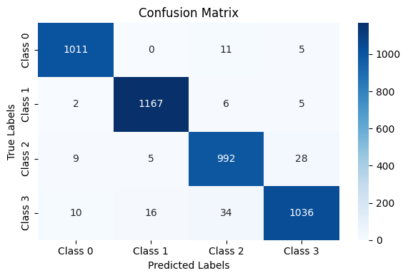

```python
import numpy as np
import matplotlib.pyplot as plt
import seaborn as sns
from sklearn.metrics import confusion_matrix

# Step 1: Generate the confusion matrix
conf_matrix_val = confusion_matrix(y_val, predictions_val)

# Step 2: Plot the confusion matrix

labels = ['Class 0', 'Class 1', 'Class 2', 'Class 3']  #

plt.figure(figsize=(6, 4))
sns.heatmap(conf_matrix_val, annot=True, fmt="d", cmap="Blues", xticklabels=labels, yticklabels=labels)

plt.title('Confusion Matrix')  # You can customize the title
plt.xlabel('Predicted Labels')  # X-axis label
plt.ylabel('True Labels')  # Y-axis label
plt.tight_layout()  # Adjusts subplot params for the subplot(s) to fit in to the figure area.
plt.show()
```

### 5.3. Precision-recall curve for class 0 e vs. all others:

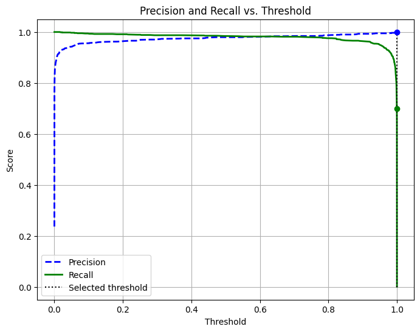

```python
import numpy as np
import matplotlib.pyplot as plt
from sklearn.metrics import precision_recall_curve, average_precision_score

# Assuming logisticRegr is your trained Logistic Regression model
# and X_val_scaled is your scaled validation set.

# Get the probability scores for class 0
y_scores = logisticRegr.predict_proba(X_val_scaled)[:, 0]

# Binarize the validation set labels - 1 for class 0, 0 for all other classes
y_true = (y_val == 0).astype(int)

# Calculate precision and recall for various thresholds
precision, recall, thresholds = precision_recall_curve(y_true, y_scores)

# Calculate the average precision score
average_precision = average_precision_score(y_true, y_scores)

# Assuming y_scores are the probability scores for class 0 from the logistic regression model
precision, recall, thresholds = precision_recall_curve(y_true, y_scores)

# Selecting a threshold for demonstration. For example, choosing the threshold that gives the highest precision with recall above some value
# This is a simple method to select a threshold, adjust according to your criteria
recall_threshold = 0.7
idx = np.where(recall >= recall_threshold)[0][-1]  # Last index where recall is above the threshold
selected_threshold = thresholds[idx]

# Plotting
plt.figure(figsize=(8, 6))
plt.plot(thresholds, precision[:-1], "b--", label="Precision", linewidth=2)
plt.plot(thresholds, recall[:-1], "g-", label="Recall", linewidth=2)
plt.vlines(selected_threshold, 0, 1.0, "k", "dotted", label="Selected threshold")
plt.plot(thresholds[idx], precision[idx], "bo")  # Marking the selected threshold on precision curve
plt.plot(thresholds[idx], recall[idx], "go")  # Marking the selected threshold on recall curve
plt.xlabel("Threshold")
plt.ylabel("Score")
plt.title("Precision and Recall vs. Threshold")
plt.legend(loc="best")
plt.grid(True)
plt.show()
```

### Providing insights in the Precision-recall curve for class 0 e vs. all others:

First, we must understand the threshold, a value typically between 0 and 1 that determines the point at which a probability prediction is classified as the positive class.

In this graph, recall decreases after a certain point as the threshold increases. This suggests the model begins to miss more true positives as it becomes more conservative in predicting positives. Precision, remains high and stable as the threshold increases, indicating that the model remains accurate in its positive predictions.

### 5.4. Assume that you want to increase precision for your chosen class without retraining the model - what will you do?

To increase precision for a chosen class without retraining the model, you can adjust the decision threshold used to classify instances. By default, a classifier like Logistic Regression uses a threshold of 0.5 for binary classification, so we are going to increase it to 0.7, this adjustment will increase the precision, as can be seen in the code below:

```python
import numpy as np
from sklearn.metrics import precision_score, recall_score


# Get probability estimates for class 0 for each instance in the validation set
probabilities = logisticRegr.predict_proba(X_val_scaled)[:, 0]  # Probabilities for class 0

# Default threshold is 0.5
default_threshold_predictions = (probabilities >= 0.5).astype(int)
default_precision = precision_score(y_val == 0, default_threshold_predictions)
default_recall = recall_score(y_val == 0, default_threshold_predictions)

# Increasing the threshold to 0.7 to prioritize precision
increased_threshold = 0.7
increased_threshold_predictions = (probabilities >= increased_threshold).astype(int)
increased_precision = precision_score(y_val == 0, increased_threshold_predictions)
increased_recall = recall_score(y_val == 0, increased_threshold_predictions)

(default_precision, default_recall, increased_precision, increased_recall)


#Constructing the print statement
print(f"Default threshold (0.5): Precision = {default_precision}, Recall = {default_recall}\n"
      f"Increased threshold (0.7): Precision = {increased_precision}, Recall = {increased_recall}\n")
```

```
Default threshold (0.5): Precision = 0.979631425800194, Recall = 0.9834469328140214
Increased threshold (0.7): Precision = 0.984375, Recall = 0.9814995131450828
```

### 5.5. Assume that you want to increase recall for your chosen class without retraining the model - what will you do?

To increase recall for a chosen class without retraining the model, you can adjust the decision threshold used to classify instances. By default, a classifier like Logistic Regression uses a threshold of 0.5 for binary classification, so we are going to decrease it to 0.3, this adjustment will increase recall, as can be seen in the code below:

```python
# Decreasing the threshold to 0.3 to prioritize recall
decreased_threshold = 0.3
decreased_threshold_predictions = (probabilities >= decreased_threshold).astype(int)
decreased_precision = precision_score(y_val == 0, decreased_threshold_predictions)
decreased_recall = recall_score(y_val == 0, decreased_threshold_predictions)

# Print statement to show the effect of decreasing the threshold on precision and recall
print(f"Default threshold (0.5): Precision = {default_precision}, Recall = {default_recall}\n"
      f"Decreased threshold (0.3): Precision = {decreased_precision}, Recall = {decreased_recall}\n")
```

```
Default threshold (0.5): Precision = 0.979631425800194, Recall = 0.9834469328140214
Decreased threshold (0.3): Precision = 0.9712643678160919, Recall = 0.9873417721518988
```

# 6. Conclusions: Run on the test set, and provide your conclusions

```python
# Predictions and evaluation on the test set
predictions_test = logisticRegr.predict(X_test_scaled)
accuracy_test = accuracy_score(y_test, predictions_test)


accuracy_test
```

```
0.9684113442471755
```